# Connecticut Waze Crash Models

#### Background

The Safety Data Initiative Waze project aims to estimate the patterns and processes associated with roadway crashes, based on crowdsourced Waze predictors. Maryland is one of several states that contributes crash data to the Electronic Data Transfer (EDT) system, with high quality crash location data available for most records. The first phase of the effort in early 2018 focused on estimating traffic crash counts using EDT and the six months of 2017 Waze data available for Maryland at that time. Crash estimation models (random forests) were trained on the presence or absence of EDT crashes (binary), in each 1 mile grid cell, for each hour of the study period with reported Waze events. Combinations of a large number of predictors such as number of Waze accidents, the type of Waze events, number of Waze events in total, and other auxiliary variables were tested to identify the models that best estimated the presence and absence of EDT crashes.

A model trained on observed EDT crash data can be employed to estimate crash counts using Waze input variables to estimate the number and spatial/temporal pattern of EDT-level crashes for times or states when EDT data are not available. In the model development process, the model is first trained on a majority (e.g, 70%) of the complete data. The remainder of the complete data is used to assess the model performance; the estimates produced by the model fit to training data can be compared to the observed EDT data. A goal of the SDI Waze project is to produce estimated EDT-level crash counts which best fit the observed data in terms of overall accuracy and precision in spatial and temporal patterns.

- Average annual daily traffic (AADT), summed for all the roads in a grid cell, from HPMS.
- Fatal Accident Reporting System (FARS) counts of fatal accidents from 2012-2016 for each grid cell.
- Weather: Reflectivity from the [NEXRAD](https://www.ncdc.noaa.gov/data-access/radar-data/nexrad) radar network, pulled hourly and merged with gridded data.
- Road functional class: Miles of roads of each functional class, from [HPMS](https://www.fhwa.dot.gov/policyinformation/hpms.cfm).
- Economic data from [Longidtinal Employer-Household Dynamics (LEHD)](https://lehd.ces.census.gov/) data set: Number of jobs, and number of workers, for firms of different ages and sizes.

#### Application to Connecticut

To extend the work of the first phase to additional states, Connecticut was selected in the second phase of the SDI Waze project. Like Maryland, crashes are reported in the EDT system for Connecticut, and spatial data are high quality and high coverage across crashes (i.e., relatively few crashes have no spatial data). Two sets of models were applied, a *simple* model using only Waze variables (32 different variables), and a *full* model with an additional 26 variables from AADT, vehicle miles traveled (VMT) by road functional class, FARS, and LEHD economic variables.

As a test of the approach taken in the first phase, a model of police-reportable crashes using just Waze data features (without supplemental data) was applied to Connecticut, for the same April - September 2017 time period (the simple model, below). We then compare this Connecticut model to the Maryland model, and repeat the test for the full model (with supplemental data). There are three questions to ask in this comparison:

1. Do the Connecticut and Maryland models have similar accuracy, precision, recall, and false positive rates?
2. Do the Connecticut and Maryland models have similar variables identified as the most important?
3. When applying models fitted to one state on to data from another state, how much does the accuracy and other model diagnostic information change?

For both Maryland and Connecticut, there are two key data sets:

- EDT data, April - September 2017
- Waze data, April - September 2017

For both simple and full random forest models, models were fitted using 70% of the data (by grid cell and hour). Then, again within each state, 30% of data was used to test the fitted model. Observed EDT crashes are compared to estimated EDT crashes produced by the model.

## Question 1: Do the Connecticut and Maryland models have similar accuracy, precision, recall, and false positive rates?

|  | Accuracy | Precision | Recall | False Positive Rate | AUC |
| --- | --- | --- | --- | --- | --- |
| Maryland, simple Waze model | 99 | 56.1 | 52.1 | 0.46 | 0.9641 |
| Connecticut, simple Waze model | 99.16 | 58.2 | 70.75 | 0.54 | 0.984 |
| Maryland, full Waze model | 98.96 | 52.84 | 64.36 | 0.65 | 0.9938 |
| Connecticut, full Waze model | 99.18 | 57.29 | 81.53 | 0.64 | 0.9953 |

## Question 2. Do the Connecticut and Maryland models have similar variables identified as the most imporant?

Comparing the variables used in the individual state models, the single most important variable for both states was the number of Waze accidents reported in a grid cell, in an hour. This confirms the strong link between user-reported crashes (called ‘accidents’ in the Waze data) and police-reported crashes. The strength of importance is measured with Gini importance, which reflects how much the inclusion of this variable improves the classification of the outcome variable, number of estimated EDT crashes. The units of importance have been normalized across all variables used in these models (32 variables in the simple model, 58 in the full model).

### Simple model

#### Rank importance table

|  | var | CT_rank | CT_Importance | MD_rank | MD_Importance |
| --- | --- | --- | --- | --- | --- |
| 1 | nWazeAccident | 1 | 59.4961126868778 | 1 | 51.6032082976722 |
| 2 | nWazeAccidentMinor | 2 | 13.388566742942 | 3 | 9.43659041181511 |
| 3 | nWazeAccidentMajor | 3 | 7.12173695346108 | 2 | 18.251237840829 |
| 4 | nWazeRT3 | 4 | 2.64913464851559 | 6 | 1.753946336758 |
| 5 | nWazeRT6 | 5 | 1.9225499404757 | 7 | 1.59005332280968 |
| 6 | hour | 6 | 1.88791213035757 | 4 | 2.30352333074266 |
| 7 | DayOfWeek | 7 | 1.60151621005854 | 5 | 1.7850234350421 |
| 8 | nWazeRT7 | 8 | 1.58424663996951 | 9 | 1.20133915708686 |
| 9 | nWazeJam | 9 | 0.980771969040701 | 8 | 1.25147254789437 |
| 10 | nWazeRT1 | 10 | 0.928258617140479 | 10 | 1.06600572486298 |

[output cut: 18 more lines]

#### Variable Importance figure *(click to view)*

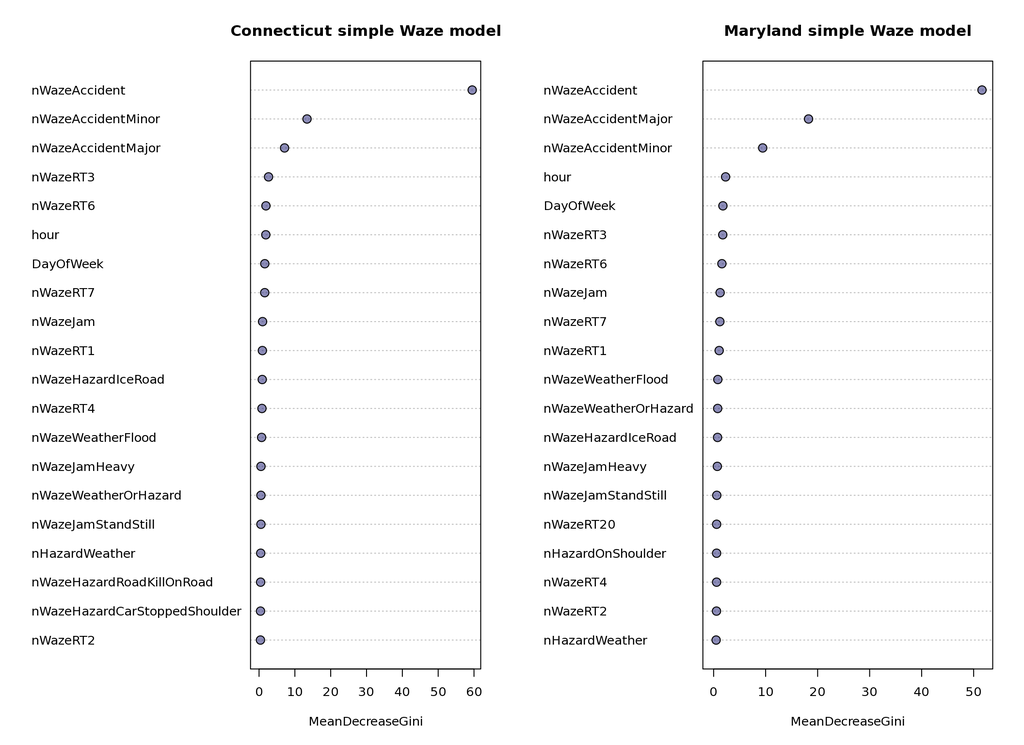

### Full model

For the full model, using VMT and other supplemental variables, the identity of the top seven variables was the same for both states, but the order slightly different. In the full model, number of jams reported was the second most important variable in Maryland, while in Connecticut that was the fourth most important variable. Hourly VMT and economic variables were important in both states.

#### Rank importance table

|  | var | CT_rank | CT_Importance | MD_rank | MD_Importance |
| --- | --- | --- | --- | --- | --- |
| 1 | nWazeAccident | 1 | 67.033046702773 | 1 | 63.4539343256146 |
| 2 | nWazeRT3 | 2 | 3.84646554852163 | 5 | 1.78082610672573 |
| 3 | medLastRepRate | 3 | 3.20662504625879 | 3 | 2.64224039547909 |
| 4 | nWazeJam | 4 | 2.87761680796157 | 2 | 4.19248180103383 |
| 5 | nWazeRT6 | 5 | 1.38929535978165 | 4 | 2.01362591576357 |
| 6 | medMagVar | 6 | 1.20067285410044 | 7 | 1.33306060213397 |
| 7 | nWazeWeatherOrHazard | 7 | 1.17243196589881 | 6 | 1.77476047127529 |
| 8 | nWazeRT7 | 8 | 1.00930435975925 | 10 | 1.03240981380911 |
| 9 | HOURLY_MAX_AADT_3 | 9 | 0.919043302190573 | 12 | 0.963179689076229 |
| 10 | DayOfWeek | 10 | 0.834256879535089 | 9 | 1.08143913792171 |

[output cut: 16 more lines]

#### Variable importance figure *(click to view)*

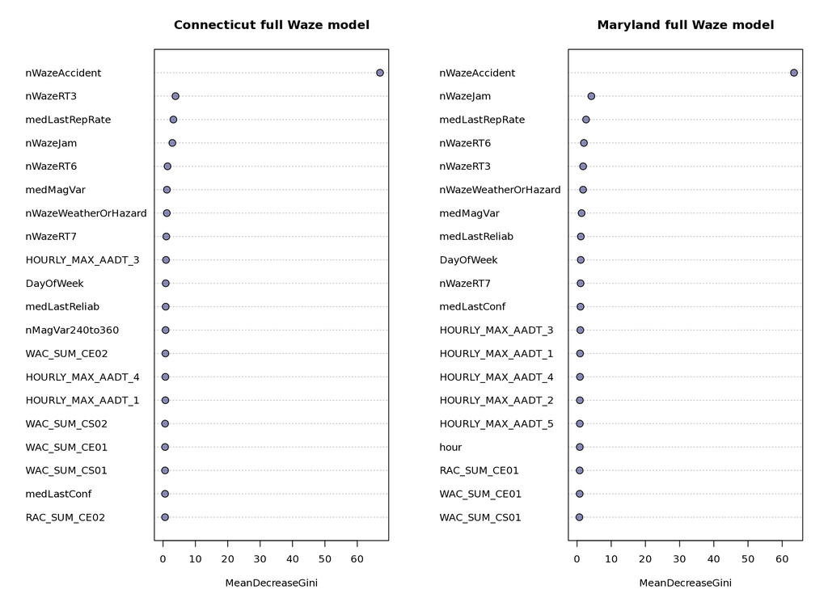

## Question 3. When applying models fitted to one state to data from another state, how does model performance change?

To answer this question, we used models trained on one state (e.g., Maryland) and applied it to the full set of data from the other state (e.g., Connecticut). This process would be similar to what would be done if applying this approach to estimating police-reportable crashes for states where EDT data are not available.

|  | Accuracy | Precision | Recall | False Positive Rate | AUC |
| --- | --- | --- | --- | --- | --- |
| MD Waze model on CT data, simple | 99.24 | 60.88 | 74.47 | 0.5 | 0.9881 |
| CT Waze model on MD data, simple | 98.49 | 41.51 | 81.69 | 1.32 | 0.9875 |
| MD Waze model on CT data, full | 98.74 | 64.95 | 57.46 | 0.54 | 0.9939 |
| CT Waze model on MD data, full | 97.51 | 38.39 | 92.74 | 2.41 | 0.9902 |

### CT / MD models summary

What we learned from this testing is the following:

1. All models showed very high accuracy and excellent performance according to model diagnostics, especially accuracy and AUC.
2. Connecticut and Maryland models fitted with the Waze data showed very similar order and level of importance for the input variables.
3. Applying the Connecticut model to Maryland data and vice versa showed similar model performance, giving confidence that the relationships between the crowdsourced crash reports and police-reported crashes are robust. In addition, the Waze data can be used as inputs for a crash-estimation model across states, even when EDT data may not be available.

## Appendix 1: Model comparison metrics

There are multiple criteria for evaluating classification models like random forests. For all the models, we used two different data sets to train and test the model. *Training* refers to fitting the model parameters with a large set of known EDT crashes and associated Waze events and other predictors, while *testing* refers to applying the fitted model parameters to a new set of Waze events and other predictors, generating estimated EDT crashes. The estimated EDT crashes are then compared to the known, observed EDT crashes in the test data set to evaluate model performance.

Here we use two criteria:

### 1. Diagnostics from a confusion matrix

For binary classification models, it is possible to create a 2x2 table where columns are observed negative and positive, and rows are predicted negative and positive. This is know as a *confusion matrix*, and shows four quantities to represent model performance:

|  |  | OBSERVED |  |
| --- | --- | --- | --- |
|  |  | Positive | Negative |
| **PREDICTED** | Positive | TP | FP |
|  | Negative | FN | TN |

False positives (FP) can be considered Type I errors, and false negatives (FN) can be considered Type II errors.

- *Accuracy* = ( TN + TP ) / All observations
  - True positives and true negatives divided by all observations. A high value indicates that the observed occurrences and absences of EDT crashes are correctly being estimated.
- *Precision* = TP / ( FP + TP )
  - True positives divided by all predicted positives. A high value indicates that there are relatively few false positives (locations and times where a crash is estimated, but did not actually occur).
- *Recall* = TP / ( FN + TP )
  - True positives divided by all observed positives. This is also called *Sensitivity*, or the *true postitive rate*. A high value indicates that there are relatively few false negatives (locations and times where a crash was not estimated, but did actually occur).
- *False Positive Rate* = FP / ( TN + FP )
  - False positives divided by all observed negatives. A low value indicates that there are relatively few false positives compared to all observed absences of EDT crashes.

### 2. Area under Reciever-Operator Characteristic Curve (AUC, AUROC, ROC curve)

For a binary model, we can additionally calculate one other quantity:

- *Specificity* = TN / ( TN + FP )
- True negatives divided by all observed negatives, also called the true negative rate. For the SDI Waze analysis, most observations are “0”, meaning no EDT crashes occurred, so much of the model performance is driven by accurately predicting these “0” (no crash) values.

Balancing between high specificity (where false positives are avoided) and high sensitivity (where false negatives are avoided) is an important decision point in evaluating a model. High sensitivity (i.e., recall or true positive rate) with high specificity (low false positive rate) is ideal. Plotting the false positive rate versus the true positive rate allows a visualization of this balance, and is known the ‘receiver-operator characteristic (ROC) curve’. The larger the area under the ROC curve, the more high specificity is maximized with low loss of sensitivity. An area of 0.5 is equivalent to flipping a coin; and area of 1 is perfect estimation, with no false positives or false negatives. As a rule of thumb, areas of 0.6 or greater are generally considered to represent useful classification models; areas of 0.9 or greater are considered to represent very good classification models.

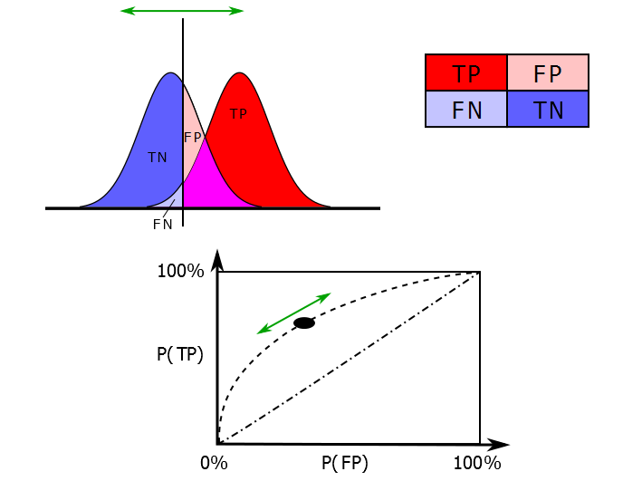

ROC curves, [CC BY-SA 3.0 Wikimedia](https://commons.wikimedia.org/w/index.php?curid=44059691)

## Appendix 2: Data dictionary

Explanation of selected variables used in the random forest models.

| Variable | Notes |
| --- | --- |
| nWazeAccident | Count of Waze crash reports |
| nWazeJam | Count of Waze jam reports |
| nWazeRoadClosed | Count of Waze road closure reports |
| nWazeWeatherOrHazard | Count of Waze Weather or Hazard reports |
| nWazeRT3 | Count of Waze reports on freeways |
| nWazeRT6 | Count of Waze reports on primary roads |
| nWazeRT7 | Count of Waze reports on secondary roads |
| medLastRepRate | Median value of Waze report ratings |
| medLastConf | Median value of Waze confidence ratings |
| medLastReliab | Median value of Waze reliability ratings |
| medMagVar | Median value of direction of travel |
| nMagVar240to360 | Count of Waze report traveling at heading of 240-360 degrees |
| DayOfWeek | Day of Week |
| HOURLY_MAX_AADT_1 | Maximum hourly AADT share on interstates (F_1) |
| HOURLY_MAX_AADT_2 | Maximum hourly AADT share on principal arterials - other freeways and expressways (F_2) |
| HOURLY_MAX_AADT_3 | Maximum hourly AADT share on principal arterials - others (F_3) |
| HOURLY_MAX_AADT_4 | Maximum hourly AADT share on minor arterials (F_4) |
| HOURLY_MAX_AADT_5 | Maximum hourly AADT share on major collectors (F_5) |
| WAC_SUM_CE01 | Sum of Workplace Area Characteristics from LEHD: number of jobs earning $1250/month or less |
| WAC_SUM_CE02 | Sum of Workplace Area Characteristics from LEHD: number of jobs earning $1251 to $3333/month |
| WAC_SUM_CS01 | Sum of Workplace Area Characteristics from LEHD: number of jobs for workers with Sex: Male |
| RAC_SUM_CE02 | Sum of Residence Area Characteristics from LEHD: number of jobs earning $1251 to $3333/month |
| nHazardWeather | Count of Waze hazard reports, sub-type weather |
| nWazeAccidentMajor | Count of Waze crash reports, sub-type major |
| nWazeAccidentMinor | Count of Waze crash reports, sub-type minor |
| nWazeHazardCarStoppedRoad | Count of Waze hazard reports, sub-type car stopped on road |
| nWazeHazardCarStoppedShoulder | Count of Waze hazard reports, sub-type car stopped on shoulder |
| nWazeJamHeavy | Count of Waze jam reports, sub-type heavy |
| nWazeJamStandStill | Count of Waze jam reports, sub-type standstill |
| nWazeWeatherFlood | Count of Waze hazard reports, sub-type weather/flood |